# Problema 4 - Checkpoint 3

## Descrição dos dados

Esse estudo tem como base uma *amostra* dos dados da atividade global do [GitHub](https://github.com/). Os dados contém a contagem de quantas pessoas editaram arquivos com cada extensão de arquivo em cada dia de 2016 e em alguns meses de 2017.

```r
dados <- read.csv("github-users-committing-filetypes.csv")
```

Para responder as questões desse estudo serão necessárias algumas transformações nos dados, de modo a obter a data completa e o dia da semana de cada observação.

```r
dados <- dados %>%
  unite("data", the_year, the_month, month_day, sep = "-") %>%
  mutate(data = as.Date(strptime(data, "%Y-%m-%d"))) %>%
  mutate(dia_da_semana = weekdays(data)) %>%
  mutate(mes = month(data)) %>%
  mutate(fds = is.weekend(data)) %>%
  mutate(is_segsex = dia_da_semana %in% c("segunda", "sexta"))
```

## Visão Geral

As questões desta análise são todas de cunho temporal, assim sendo, a visualização abaixo pode lhe ajudar a entender o comportamento da amostra com a qual estamos lidando.

É possível observar vários períodos de tempo diferentes neste gráfico, divirta-se!

```r
dados_ <- dados %>%
  select(-c(file_extension, fds, dia_da_semana)) %>%
  group_by(data) %>%
  summarise(users_tot = sum(users)) %>%
  remove_rownames %>%
  column_to_rownames(var="data") %>%
  as.xts()

highchart(type = "stock") %>%
  hc_title(text = "Timeline da Atividade Geral do Github") %>%
  hc_add_series(dados_)
```

[interactive chart not shown]

Agora que já compreendemos o comportamento temporal da amostra que temos as questões a seguir se dedicação à utilização de manipulações estatísticas sobre esta amostra para obtermos concluções acerca da população que são os usuários do GitHub.

## Existe diferença na produtividade no primeiro e no segundo semestre de 2016?

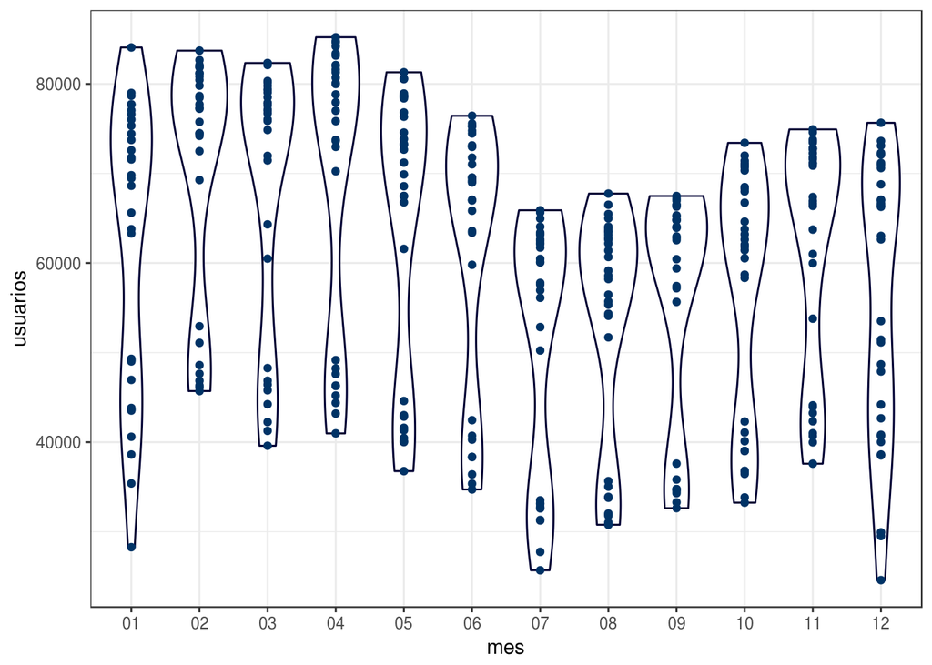

```r
dados.semestre <- dados %>%
  filter(substr(data, 0,  4) == "2016") %>%
  mutate(Sem1 = mes <= 6) %>%
  select(users, mes, Sem1, data)

dados.semestre.group <- dados.semestre %>%
  group_by(mes = substr(data, 6,  7), dia = substr(data, 9,  10)) %>%
  summarize(usuarios = sum(users))


ggplot(data = dados.semestre.group, aes(x = mes, y = usuarios)) +
  geom_violin(color = "#000033") +
  geom_point(color = "#003366")
```

A visualização a acima nos dá a ideia de que a atividade é superior no primeiro semestre, mas será que podemos generalizar essa conclução para a amostra?

Aqui determinaremos o intevalo de confiança para a atividade dos programadores para os semestres do ano de 2016.

Usaremos como medida a mediana, por ser uma métrica mais robusta.

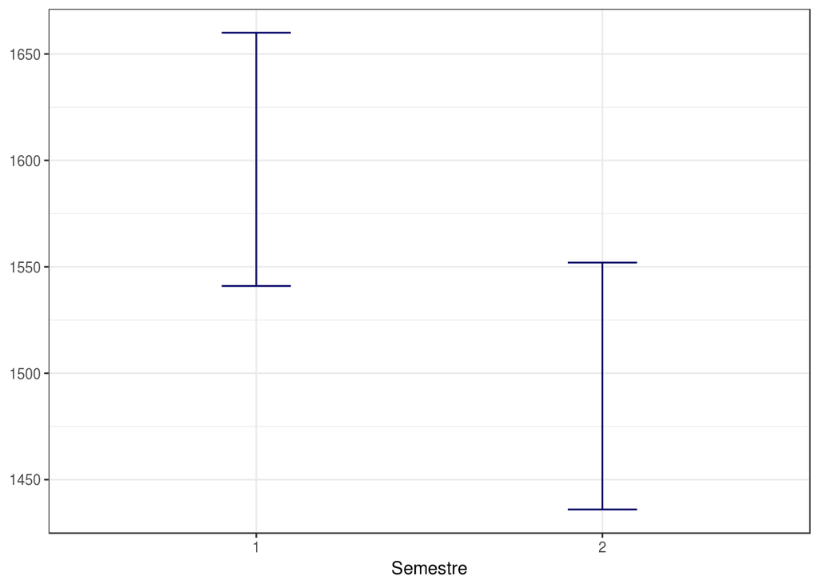

```r
b_sem1 <- bootstrap(dados.semestre %>%
                filter(Sem1), median(users))

sem1.CI <- CI.percentile(b_sem1, probs = c(.025, .975))


b_sem2 <- bootstrap(dados.semestre %>%
                filter(!Sem1), median(users))

sem2.CI <- CI.percentile(b_sem2, probs = c(.025, .975))


df.sem <- data.frame(rbind(sem1.CI,
                       sem2.CI))

df.sem$Semestre = row.names(df.sem)

df.sem %>%
  ggplot(aes(x = Semestre, ymin = X2.5., ymax = X97.5.)) +
  geom_errorbar(width = .2, color = "#000066")
```

É perceptível que existe maior produtividade no primeiro semestre do ano.

Podemos ainda observar o intervalo de confiança da diferença da produtividade no primeiro e no segundo semestre.

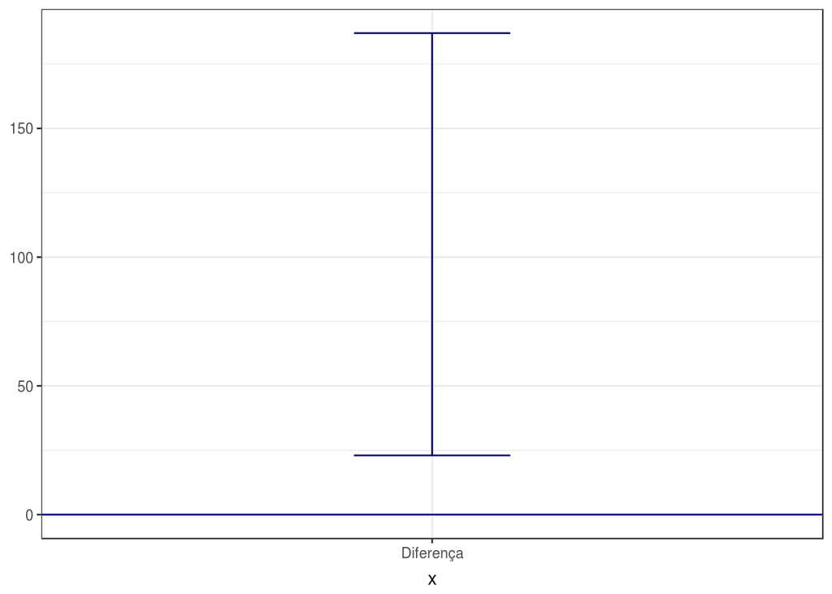

```r
b_diff <- bootstrap2(data = (dados.semestre %>%
                               filter(Sem1))$users,
                     data2 = (dados.semestre %>%
                               filter(!Sem1))$users,
                     median)

b_diff.ci <- CI.percentile(b_diff, probs = c(.025, .975))

data.frame(b_diff.ci) %>%
  ggplot(aes(x = "Diferença", ymin = X2.5., ymax = X97.5.)) +
  geom_errorbar(width = .2, color = "#000066") +
  geom_hline(yintercept = 0, colour = "darkblue")
```

Enfim, podemos afirmar com 95% de confiança que a atividade dos programadores no GitHub é superior no primeiro semestre. O intervalo de confiança da diferença é 23, 187.

## Sabendo que em geral a produtividade é maior no primeiro semestre, em que trimestre desse período a produtividade é maior?

Já que sabemos que no primeiro semestre a produtividade é maior, mas será que ao observarmos os trimestres teremos diferença significativa também?

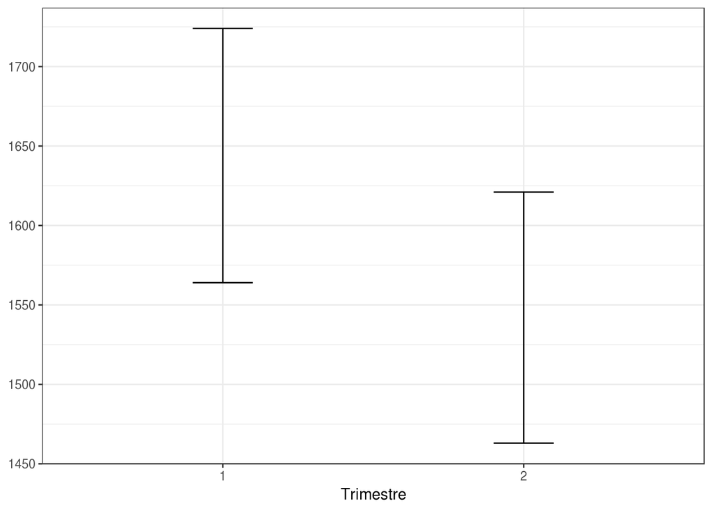

```r
dados.tri <- dados.semestre %>%
  filter(Sem1) %>%
  mutate(Sem1 = NULL) %>%
  mutate(trim1 = as.numeric(mes) <= 3)


b_trim1 <- bootstrap(dados.tri %>%
                filter(trim1), median(users))

trim1.CI <- CI.percentile(b_trim1, probs = c(.025, .975))


b_trim2 <- bootstrap(dados.tri %>%
                filter(!trim1), median(users))

trim2.CI <- CI.percentile(b_trim2, probs = c(.025, .975))


df.trim <- data.frame(rbind(trim1.CI,
                       trim2.CI))

df.trim$Trimestre = row.names(df.trim)

df.trim %>%
  ggplot(aes(x = Trimestre, ymin = X2.5., ymax = X97.5.)) +
  geom_errorbar(width = .2)
```

Neste caso temos bastante interseção entre os intervalos, então precisaremos observar a diferença entre os intervalos, para sabermos se podemos obter conclusões significativas sobre a população.

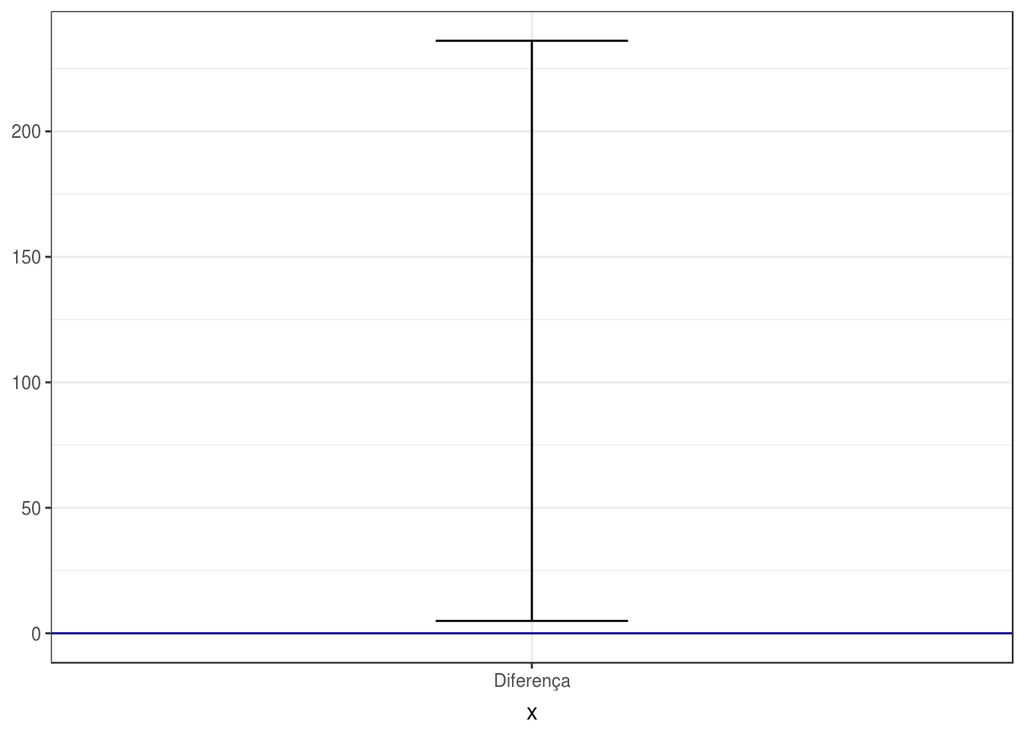

```r
b_diff <- bootstrap2(data = (dados.tri %>%
                               filter(trim1))$users,
                     data2 = (dados.tri %>%
                               filter(!trim1))$users,
                     statistic = median,
                     R = 1000)

b_diff.ci <- CI.percentile(b_diff, probs = c(.025, .975))

data.frame(b_diff.ci) %>%
  ggplot(aes(x = "Diferença", ymin = X2.5., ymax = X97.5.)) +
  geom_errorbar(width = .2) +
  geom_hline(yintercept = 0, colour = "darkblue")
```

Observa-se que mesmo com o intervalo bem próximo ao zero, no entanto o zero não está contido nele, logo, podemos afirmar com 95% de confiança que a produtividade dos usuários do GitHub no primeiro trimestre é superior à do segundo trimestre do ano. O intervalo de confiança é 4.952341, 236.095318.

## Existe diferença no número de usuários nos dias próximos ao fim de semana (segunda e sexta) e os do meio da semana (terça, quarta e quinta)?

Será que o fim de semana afeta a produtividade dos usuários do GitHub durante a semana? Usaremos como métrica a mediana novamente.

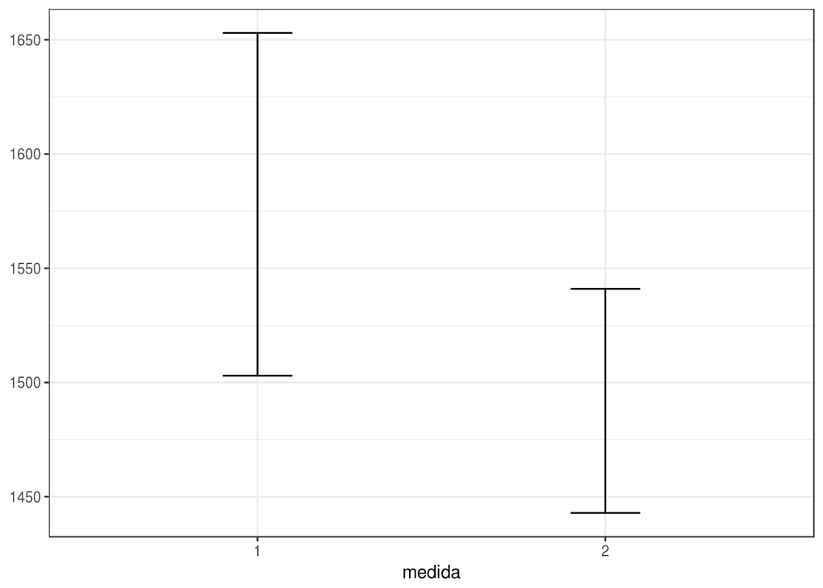

```r
dados.ss = bootstrap(dados %>%
                filter(is_segsex), median(users))

ss.CI = CI.percentile(dados.ss, probs = c(.025, .975))


dados.Nss = bootstrap(dados %>%
                filter(!is_segsex), median(users))

Nss.CI = CI.percentile(dados.Nss, probs = c(.025, .975))


df <- data.frame(rbind(ss.CI,
                       Nss.CI))

df$medida = row.names(df)

df %>%
  ggplot(aes(x = medida, ymin = X2.5., ymax = X97.5.)) +
  geom_errorbar(width = .2)
```

Temos bastante interseção entre os intervalos, então precisaremos observar a diferença para termos certeza sobre as conclusão que iremos obter.

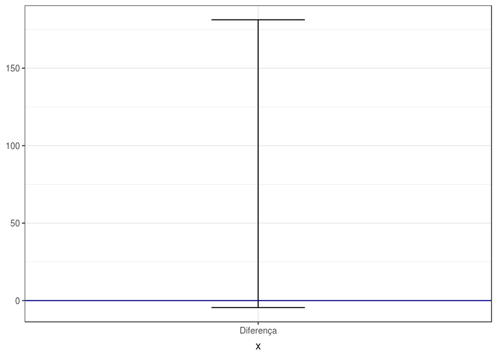

```r
mSS <- bootstrap2(data = (dados %>% filter(is_segsex))$users,
                  data2 = (dados %>% filter(!is_segsex))$users,
                  median,
                  R = 10000)

mSS.CI <- CI.percentile(mSS, probs = c(.025, .975))

data.frame(mSS.CI) %>%
  ggplot(aes(x = "Diferença", ymin = X2.5., ymax = X97.5.)) +
  geom_errorbar(width = .2) +
  geom_hline(yintercept = 0, colour = "darkblue")
```

Como o intervalo da diferença (-4.5, 181.2252269) inclui o zero não podemos obter conclusões significativas para essa questão.

## Existe uma diferença significativa na sua variação do número de usuários do GitHub entre os dias próximos ao fim de semana (segunda e sexta) e os do meio da semana (terça, quarta e quinta)?

Já que não obtemos conclusões significativas sobre a popularidade, será que podemos obter resultados relevantes a cerca da variância?

Usaremos como medida o desvio padrão.

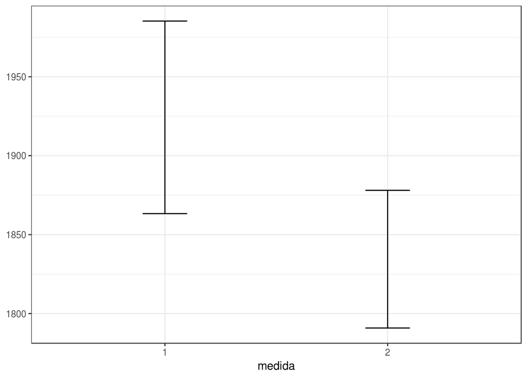

```r
dados.ss = bootstrap(dados %>%
                filter(is_segsex), sd(users))

ss.CI = CI.percentile(dados.ss, probs = c(.025, .975))


dados.Nss = bootstrap(dados %>%
                filter(!is_segsex), sd(users))

Nss.CI = CI.percentile(dados.Nss, probs = c(.025, .975))


df <- data.frame(rbind(ss.CI,
                       Nss.CI))

df$medida = row.names(df)

df %>%
  ggplot(aes(x = medida, ymin = X2.5., ymax = X97.5.)) +
  geom_errorbar(width = .2)
```

Observando a diferença:

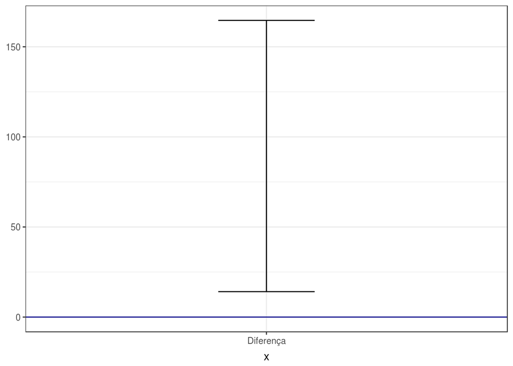

```r
mSS <- bootstrap2(data = (dados %>% filter(is_segsex))$users,
                  data2 = (dados %>% filter(!is_segsex))$users,
                  sd,
                  R = 10000)

mSS.CI <- CI.percentile(mSS, probs = c(.025, .975))

data.frame(mSS.CI) %>%
  ggplot(aes(x = "Diferença", ymin = X2.5., ymax = X97.5.)) +
  geom_errorbar(width = .2) +
  geom_hline(yintercept = 0, colour = "darkblue")
```

Observando os resultados é possível afirmar com 95% de confiança que há maior variação no número de usuários na segunda e na sexta que nos demais dias da semana útil. O itervalo de confiança é 14.1229381, 164.6361494.